# COMPARACIÓN ENTRE LAS CONVOCATORIAS COLCIENCIAS 737 DEL 2015 Y 781 DEL 2017

```python
#librerías
import numpy as np
import pandas as pd
from IPython.display import Image
from IPython.display import HTML
```

A continuación se presenta el análisis comparativo de las Convocatorias Nacionales para el Reconocimiento y Medición de Grupos de Investigación, Desarrollo Tecnológico o de Innovación y para el Reconocimiento de Investigadores del SNCTeI 737 de 2015 y 781 de 2017; para los grupos de la Universidad Tecnológica de Pereira.

## EVOLUCIÓN DE LA CLASIFICACIÓN ENTRE LAS CONVOCATORIAS 737 DE 2015 Y 781 2017

En la siguiente gráfica se evidencia que entre los dos periodos evaluados hay un incremento de grupos en cada una de las categorías de clasificación Colciencias. Se debe tener en cuenta que Colciencias eliminó la categoría "D" en la convocatoria 781 del 2017, por esta razón en la gráfica solo aparecen los datos del 2015 en este campo.

```python
evolución = Image(filename = 'images/Evolución_agregada.png')
```

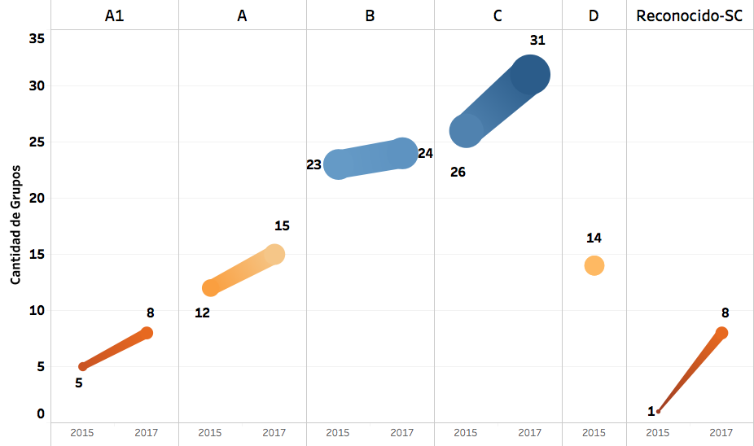

```python
evolución
```

## CLASIFICACIÓN POR FACULTADES EN EL 2015 Y EL 2017

A continuación se observan la cantidad de grupos de investigación que hay por facultad en cada categoría de la clasificación Colciencias del 2015 y el 2017. Por ejemplo, facultad de ciencias de la salud tiene mayor cantidad de grupos de investigación y además pasa de 13 grupos en la convocatoria del 2015 a 16 grupos en la del 2017.

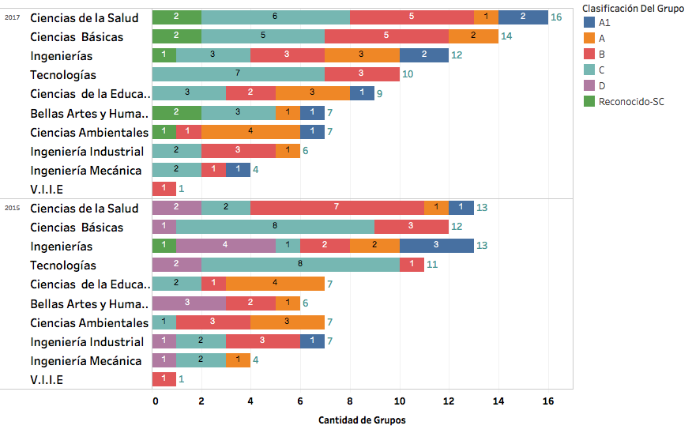

```python
por_facultad = Image(filename = 'images/781_737_clasificación_facultad.png')
por_facultad
```

# CLASIFICACIÓN POR GRAN ÁREA DE CONOCIMIENTO

En la siguiente gráfica se compara la cantidad de grupos de investigación que hay en cada área de conocimiento. También se observa, de acuerdo al color, la facultad a la que pertenecen los grupos. Por ejemplo, para la convocatoria 781 del 2017 hay 25 grupos en el área de ciencias naturales: 11 pertenecen a la facultad de ciencias básicas, 5 a la facultad de tecnologías, 4 a la facultad de ciencias ambientales, 2 a la facultad de ingeniería industrial, 2 a la facultad de ingenierías y 1 a la facultad de ciencias de la salud.

```python
por_gran_area = Image(filename = 'images/gran_area_(24-01-2018).png')
```

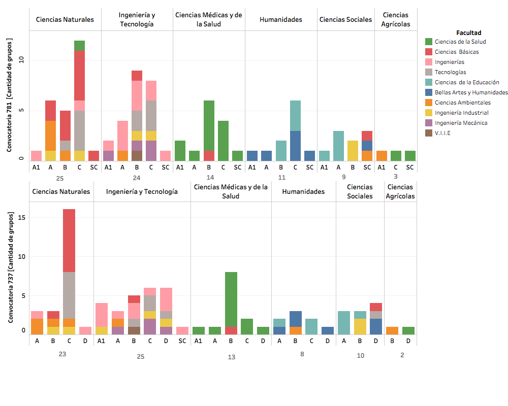

```python
por_gran_area
```

## PRODUCCIÓN CIENTÍFICA: ARTÍCULOS

En la siguiente gráfica se muestra la cantidad de artículos producidos por los grupos de investigación, dentro de las ventanas de observación válidas para las convocatorias *737* y *781*. La cantidad de artículos está agregada a nivel de facultad, por ejemplo la facultad de ciencias de la salud publicó 579 artículos válidos dentro de la ventana de observación de la convocatoria *737* y 471 dentro de la ventana de la convocatoria *781*.

```python
artículos = Image(filename = 'images/Artículos.png')
```

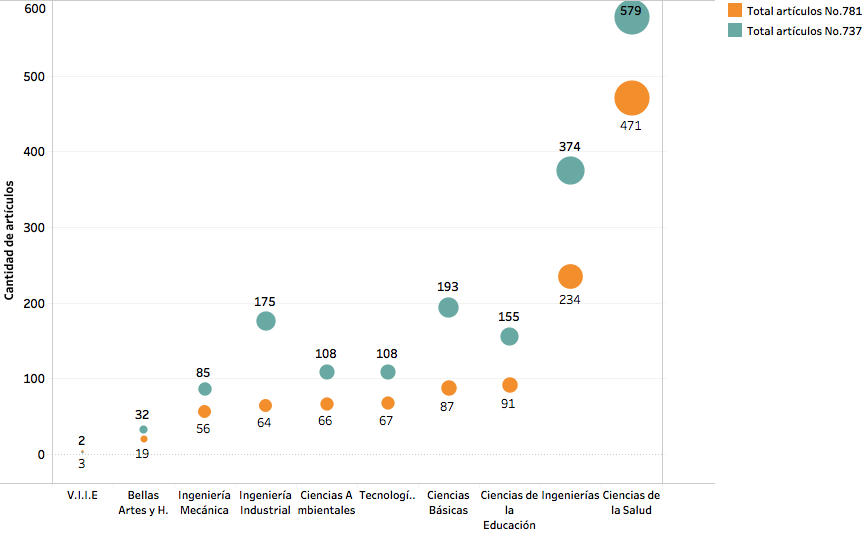

```python
artículos
```

## PRODUCCIÓN CIENTÍFICA: LIBROS

En la siguiente gráfica se muestra la cantidad de libros producidos por los grupos de investigación dentro de las ventanas de observación válidas para las convocatorias *737* y *781*. La cantidad de libros está agregada a nivel de facultad, por ejemplo la facultad de ciencias de la educación publicó 54 libros válidos dentro de la ventana de observación de la convocatoria *737* y 32 dentro de la ventana de la convocatoria *781*.

```python
libros = Image(filename = 'images/libros.png')
```

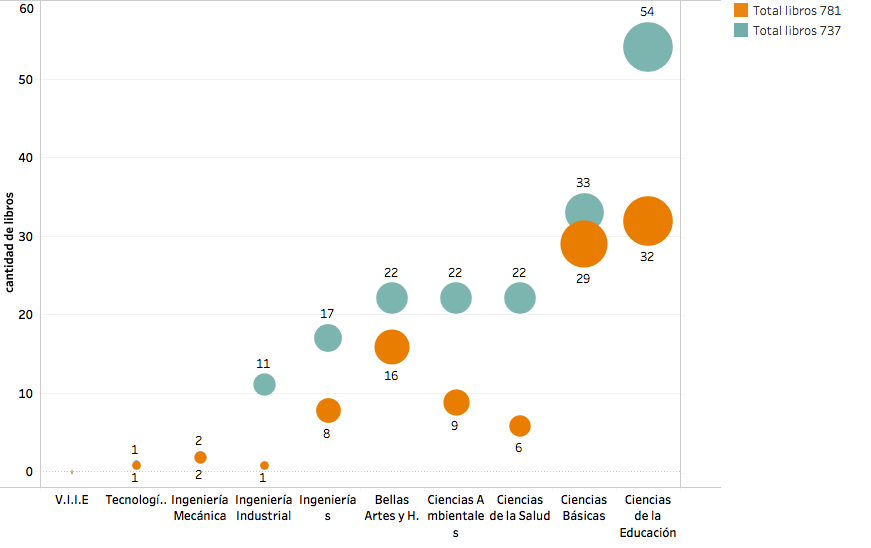

```python
libros
```

## PRODUCCIÓN CIENTÍFICA: SOFTWARE

En la siguiente gráfica se muestra la cantidad de *software* producido por los grupos de investigación dentro de las ventanas de observación válidas para las convocatorias *737* y *781*. La cantidad está agregada a nivel de facultad, por ejemplo la facultad de ingenierias registró 16 *software* válidos dentro de la ventana de observación de la convocatoria *737* y 8 dentro de la ventana de la convocatoria *781*.

```python
software = Image(filename = 'images/software.png')
```

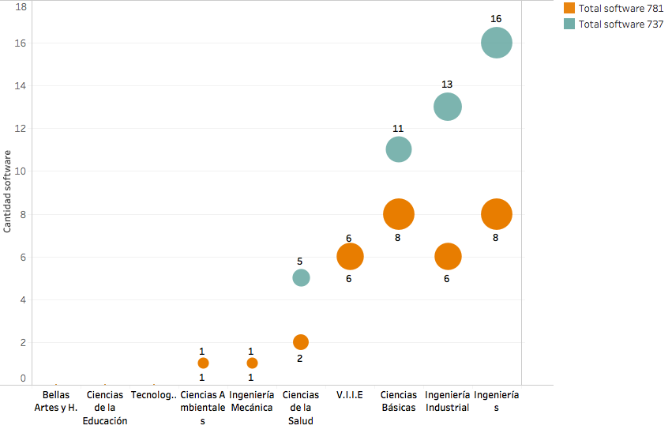

```python
software
```

Para desarrollar este informe se utilizó la información de [Scienti](http://scienti.colciencias.gov.co:8083/ciencia-war/busquedaGruposPorInstitucion.do?maxRows=15&all_grupos_ins_tr_=true&all_grupos_ins_p_=1&all_grupos_ins_mr_=15&all_grupos_ins_f_nmeInst=utp), la herramienta de consulta Colciencias.